# Biology 683 Experimental Design

Heath Blackmon

26 April 2018

## Starting your final

Go to this [website](http://coleoguy.github.io/) to download the data for your final. This website will generate a unique dataset for you to use that is linked to the last two digits of your A&M UIN. Please enter these two digits in the code block below as well.

```r
# repalce 00 with the last two digits of your UIN
student.seed <- 29
```

You should save this Rmd file and your three CSV data files that you download in the same folder and set that folder as your working directory in RStudio. Complete each of the three problems below by placing code and text in the appropriate places. Try knitting your document frequently to make sure you can discover any problems that arise. Once you have completed the exam you should be able to knit the document and have all of your answers, code, and figures come up in the final html file. If you have any confusion about how to do this please see me before you leave class today!

## Problem 1

The first step in analyzing your data is actually getting your data read in and in the correct format for analysis. When you or your lab mates record data in different programs lots of things can go wrong. Use this block of code to read your data into R and repair any problems you have discovered. Your code should be commented to describe what you are doing.

```r
#I'm reading the data in and using brackets at the end to remove rows that were bad
# this as is makes sure we dont go down the factor route
dat <- read.csv("1.csv", as.is = T)
dat <- dat[complete.cases(dat), ]

# I want to reformat this data a bit to match the function i'll use
vals <- stack(dat)
colnames(vals) <- c("size", "media")
vals$size <- as.numeric(vals$size)

# a bit of cleaning here
rm(dat)
```

The data that you have downloaded is adult body size data for flour beetles grown in four different foods. For this experiment you have two questions that you would like to answer. First you would like to know do different foods lead to different sizes of beetles and if so which foods lead to significant differences in beetle size. Describe the test(s) that you will use to answer these questions:

**I’ll do an anova followed by a tukey posthoc**

Use this code block to run the test(s) you want to perform:

```r
# First the ANOVA
fit <- lm(vals$size ~ vals$media)
a.result <- aov(fit)
summary(a.result)
```

```
##              Df Sum Sq Mean Sq F value Pr(>F)
## vals$media    3  46.41  15.470     105 <2e-16 ***
## Residuals   288  42.44   0.147
## ---
## Signif. codes:  0 '***' 0.001 '**' 0.01 '*' 0.05 '.' 0.1 ' ' 1
```

```r
# It is sig so we can do the posthoc
TukeyHSD(a.result)
```

```
##   Tukey multiple comparisons of means
##     95% family-wise confidence level
##
## Fit: aov(formula = fit)
##
## $`vals$media`
##                         diff        lwr        upr     p adj
## flour51-flour36  0.008493151 -0.1556923  0.1726786 0.9991457
## flour84-flour36 -0.807397260 -0.9715827 -0.6432118 0.0000000
## flour82-flour36 -0.778219178 -0.9424047 -0.6140337 0.0000000
## flour84-flour51 -0.815890411 -0.9800759 -0.6517049 0.0000000
## flour82-flour51 -0.786712329 -0.9508978 -0.6225269 0.0000000
## flour82-flour84  0.029178082 -0.1350074  0.1933636 0.9677797
```

Write two to three sentence description of the result of your test(s) as you would for a journal in your field of study.

**Food type has a significant impact on growth of T. castaneum as determined by a one way ANOVA (F(288, 3) = 105, p < .001). Using a Tukey posthoc test I also found that beetles grown on media 82 and 84 were significantly smaller than beetles grown on 36 and 51.**

Use this code block to produce one publication quality plot of this data in a way that does a good job of illustrating the underlying data and any differences that you have found.

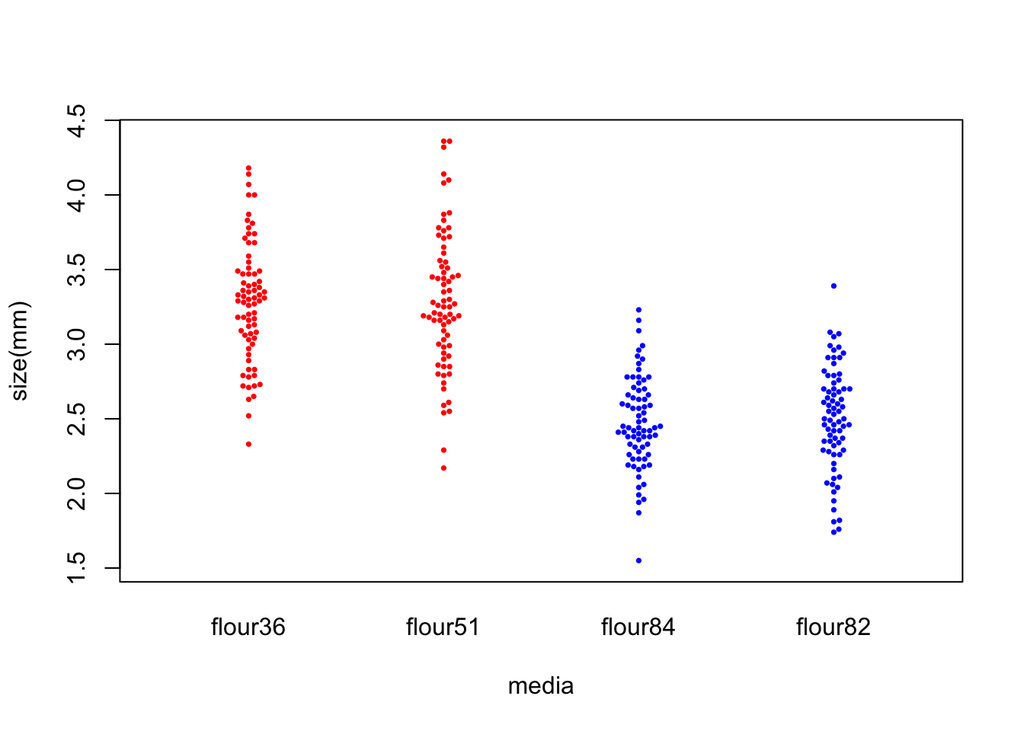

Figure 1: Beetles plotted in different colors had significantly different size based on Tukey posthoc test.

```r
# I'm going to teach the beeswarm package next year
# much easier than the stripchart function
# we used this year sorry guys :-)
library(beeswarm)
beeswarm(vals$size ~ vals$media,
         ylab = "size(mm)",
         xlab = "media",
         col = c("red", "red", "blue", "blue"),
         pch = 16,
         cex = .5)
```

## Problem 2

The data for this problem consists of generation time data for a species across a range of temperatures and in the presence of either a control substance or 2 different possible nutrient supplements.

```r
rm(list = ls())
dat <- read.csv("2.csv")
# cant have temp in 200s lets get rid of that
dat <- dat[!dat$temp.C > 50, ]
```

Your goal in this experiment is to quantify the impact that nutrient and temperature variations have on generation time in your organism. What statistical test/approach will you use:

**I will use a linear mixed model**

```r
library(nlme)
fit <- lme(gen ~ temp.C + nutrients,
           random = ~1|chamber,
           data = dat)

summary(fit)
```

```
## Linear mixed-effects model fit by REML
##  Data: dat
##         AIC       BIC   logLik
##   -556.0126 -536.3746 284.0063
##
## Random effects:
##  Formula: ~1 | chamber
##          (Intercept)   Residual
## StdDev: 5.568506e-07 0.05365566
##
## Fixed effects: gen ~ temp.C + nutrients
##                     Value  Std.Error  DF   t-value p-value
## (Intercept)     2.6288572 0.04243542 194  61.94960   0e+00
## temp.C         -0.0210479 0.00168408 194 -12.49819   0e+00
## nutrientsnut.A -0.0320950 0.00873370 194  -3.67485   3e-04
## nutrientsnut.B  0.0435504 0.01007790 194   4.32137   0e+00
##  Correlation:
##                (Intr) temp.C ntrn.A
## temp.C         -0.990
## nutrientsnut.A  0.038 -0.140
## nutrientsnut.B -0.044 -0.044  0.431
##
## Standardized Within-Group Residuals:
##          Min           Q1          Med           Q3          Max
## -2.433372630 -0.671062254  0.009030479  0.647107391  2.640813331
##
## Number of Observations: 199
## Number of Groups: 2
```

A one degree change in temperature creates how much of an expected change in generation time?

**A 1 degree increase in temperature will decrease generation time by 0.02 units.**

If you wish to minimize generation time what is the best nutrient supplement and temperature?

**Nutrient supplement A and highest temperature that was tested 29 degrees celcius.**

If you were redesigning this experiment what would you do to increase power and accuracy of your parameter estimates.

**Use a more balanced design - this test had too few B replicates.**

## Problem 3

You find that nutrient shortages during early development lead to widespread changes in gene expression that last throughout the lifespan of your organism. The dataset you have downloaded contains 500 gene expression values for 50 individuals that had limited food during early development and 50 individuals that were fed ad libitum. It also contains data from 20 wild caught individuals. The goal of this experiment is to determine if wild caught individuals experience nutrient shortages, and if so determine how common nutrient shortage is in the wild?

```r
# clean up so we don't use some old data
rm(list = ls())
dat <- read.csv("3.csv", as.is = T)
```

What statistical test/approach will you use: **I’ll use PCA**

```r
#I'm interested in genes here
gene.pca <- prcomp(dat[, 5:504])
```

Do wild caught individuals experience nutrient shortages, and if so what proportion of wild caught individuals likely experienced nutrient shortage?

**Yes about 60% of individuals expeirence food shortages.**

What other characteristic seems to impact patterns of gene expression besides feeding regime?

**Males and females tend to have distinct differnces in gene expression**

Use this code block to produce one publication quality plot of this data in a way that does a good job of illustrating the differences in gene expression in starved and well fed individuals as well as the wild caught individuals.

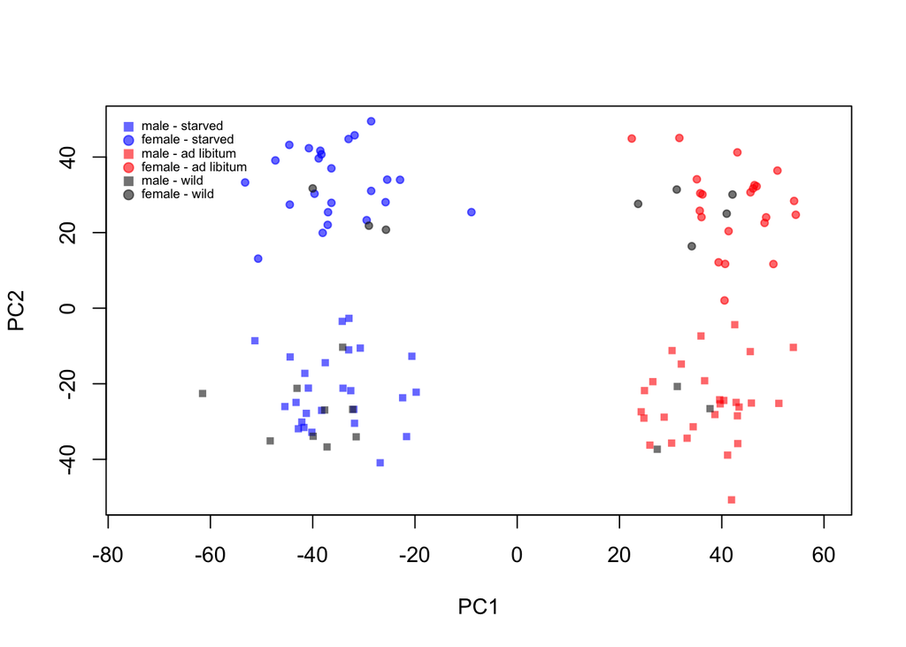

```r
# This will give us a color vector by the condition
# remember factors are alphabetical so the order will be
# ad libitum, starved, wild
cols <- c(rgb(1, 0, 0, .6),
          rgb(0, 0, 1, .6),
          rgb(.1, .1, .1, .6))[as.factor(dat$condition)]

# this will give us shapes associated with sex
# order will be female male
pchs <- c(19, 15)[as.factor(dat$sexes)]

# basic plot
plot(x = gene.pca$x[, 1],
     y = gene.pca$x[, 2],
     pch = pchs,
     col = cols,
     cex = .75,
     xlim = c(-75, 60),
     xlab = "PC1",
     ylab = "PC2")
# legend points
points(x = rep(-76, 6),
       y = seq(from = 48, to = 30, length.out = 6),
       pch = c(15, 19, 15, 19, 15, 19),
       col = c(rgb(0, 0, 1, .6),
               rgb(0, 0, 1, .6),
               rgb(1, 0, 0, .6),
               rgb(1, 0, 0, .6),
               rgb(.1, .1, .1, .6),
               rgb(.1, .1, .1, .6)))
# legend text
text(x = rep(-76, 6),
     y = seq(from = 48, to = 30, length.out = 6),
     pos = 4,
     cex = .6,
     labels = c("male - starved", "female - starved",
                "male - ad libitum", "female - ad libitum",
                "male - wild", "female - wild"))
```

## Turning in your exam

Please email me this Rmd file (I do not need your CSV files) before midnight (central time) 1 May 2018.